# Overview of spatial footprints for multiple united stratas and georeferenced data exceeding nominal in IOTC records

Bastien Grasset

IRDMARBEC  
bastien.grasset@ird.fr

Julien Barde

IRDMARBEC

17 January, 2025

Abstract

This document provide an overview of analysis of the link between gereferenced data and nominal data as well as data with multiple units for IOTC 2024 records Code for runnning the analysis: https://github.com/bastienird/iotc_report/minor_recap.R and https://github.com/bastienird/iotc_report/about.R

# 1 Strates à doubles unités avec empreintes spatiales différentes

|  | time_start | fishing_fleet | species | gear_type |
| --- | --- | --- | --- | --- |
| 1 | 1970-01-01 | TWN | BET | 09.32 |
| 2 | 1970-01-01 | TWN | MLS | 09.32 |
| 3 | 1971-02-01 | TWN | BET | 09.32 |
| 4 | 1971-02-01 | TWN | BUM | 09.32 |
| 5 | 1974-06-01 | TWN | SWO | 09.32 |
| 6 | 1985-02-01 | TWN | BUM | 09.32 |
| 7 | 1994-01-01 | AUS | SKH | 09.32 |
| 8 | 1994-01-01 | TWN | BIL | 09.32 |
| 9 | 1994-01-01 | TWN | SKJ | 09.32 |
| 10 | 1994-02-01 | AUS | ALB | 09.1 |

[output cut: 90 more lines]

Figure 1.1: Strates à doubles unités avec empreintes spatiales différentes (100 premières sur 970)

Leur nombre représente 7.56% du nombre total de strates à doubles unités.

Plus de détail et vérifications en annexe

# 2 Captures géoreferencées dépssant les captures nominales

## 2.1 Strates espèces/années

Table 2.1: Strates supérieures en Georef que en nominales sur comparaison espèces/année

| species | year | measurement_value_nominal | measurement_value_georef_tons | Difference |
| --- | --- | --- | --- | --- |
| ALB | 1993 | 20,645.13 | 25,526.43 | 4,881.30 |
| SWO | 1991 | 9,017.89 | 9,112.16 | 94.27 |
| SWO | 1992 | 15,286.91 | 20,211.76 | 4,924.85 |

Cela représente 0.11 % des captures des strates équivalentes en tonnes.

On note que pour ces données il y a en plus des données en nombre qui pourraient être converties.

Verification graphique en annexe plot de comparaison

## 2.2 Strates espèces/années/fishing_fleet

|  | species | year | fishing_fleet | measurement_value_nominal | measurement_value_georef_tons | Difference | measurement_unit | measurement_value | time_start |
| --- | --- | --- | --- | --- | --- | --- | --- | --- | --- |
| 1 | YFT | 2004 | YEM | 31524.54 | 63279.731 | 31755.191 | t | 31755.191 | 2004-01-01 |
| 2 | SKJ | 1994 | IRN | 7400 | 28793.349 | 21393.349 | t | 21393.349 | 1994-01-01 |
| 3 | BET | 1991 | TWN | 29106.9 | 49160.904 | 20054.004 | t | 20054.004 | 1991-01-01 |
| 4 | YFT | 2003 | YEM | 25548.919 | 45163.731 | 19614.812 | t | 19614.812 | 2003-01-01 |
| 5 | BET | 1992 | TWN | 24051.383 | 42287.722 | 18236.34 | t | 18236.34 | 1992-01-01 |
| 6 | YFT | 2005 | YEM | 26617.903 | 41496.523 | 14878.621 | t | 14878.621 | 2005-01-01 |
| 7 | SKJ | 2002 | NEI | 38698.94 | 52997.722 | 14298.782 | t | 14298.782 | 2002-01-01 |
| 8 | ALB | 1993 | TWN | 11933.269 | 24153.928 | 12220.659 | t | 12220.659 | 1993-01-01 |
| 9 | BET | 1999 | TWN | 37093 | 49048.207 | 11955.207 | t | 11955.207 | 1999-01-01 |
| 10 | SWO | 1992 | TWN | 9006 | 20210.646 | 11204.646 | t | 11204.646 | 1992-01-01 |

[output cut: 90 more lines]

Figure 2.1: Georef_sup_nom especes/annees/fishing_fleet juste strate de groupement

Cela représente 0.46 % des captures des strates équivalentes en tonnes.

# 3 Annexes

## 3.1 Vérification de la cohérence georef_sup_nom graphiquement

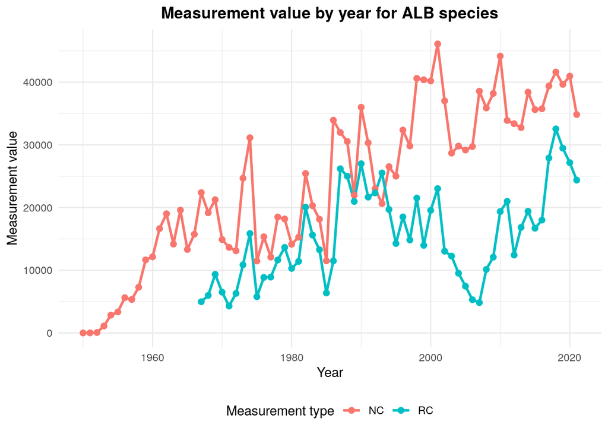

Figure 3.1: Measurement_value by year for ALB species, comparison between NC and RC

On confirme qu’en 93 il y a une inversion de la courbe de différence.

## 3.2 Verification des calculs d’empreintes spatiales différentes

Table 3.1: Données avec empreinte spatiale différentes (3 exemples)

| time_start | fishing_fleet | species | gear_type | geo_t | geo_no | identical_groups | geo_t_in_geo_no | geo_no_in_geo_t | kesako |
| --- | --- | --- | --- | --- | --- | --- | --- | --- | --- |
| 1996-09-01 | AUS | SKH | 09.32 | c(6225110, 6240145) | c(6220110, 6225110) | FALSE | FALSE | FALSE | Pas d'inclusion |
| 1970-01-01 | TWN | BET | 09.32 | c(6100045, 6100050, 6100055, 6100060, 6100080, 6100085, 6100090, 6100095, 6105050, 6105055, 6105060, 6105065, 6105085, 6105090, 6105095, 6110070, 6200040, 6200045, 6200050, 6200055, 6200075, 6200085, … | c(6100045, 6100050, 6100055, 6100060, 6100080, 6100085, 6100090, 6100095, 6105050, 6105055, 6105060, 6105065, 6105085, 6105090, 6105095, 6110070, 6200040, 6200045, 6200050, 6200055, 6200075, 6200085, … | FALSE | TRUE | FALSE | Tonnes incluses dans nombre |
| 1971-02-01 | TWN | BET | 09.32 | c(6100065, 6100075, 6100080, 6100085, 6100090, 6100095, 6105070, 6105075, 6105080, 6105085, 6105090, 6105095, 6110085, 6110090, 6115085, 6200035, 6200040, 6200045, 6200070, 6200075, 6200080, 6200085, … | c(6100065, 6100075, 6100080, 6100085, 6100090, 6100095, 6105070, 6105075, 6105080, 6105085, 6105090, 6105095, 6110085, 6110090, 6200035, 6200040, 6200045, 6200070, 6200075, 6200080, 6200085, 6200090, … | FALSE | FALSE | TRUE | Nombre inclus dans tonnnes |

## 3.3 Analyses sur la représentativité des strates à doubles unités ayant des empreintes spatiales différentes

Les pourcentages suivants sont effectué sur la base du nombre de strates ayant une double unité.

Percentage of strata with different spatial footprints : 7.56%

Percentage where tons are within numbers : 5.98%

Percentage where numbers are within tons : 93.61%

Percentage with completely different spatial footprints : 0.41%

## 3.4 Analyse de l’empreinte spatiale après aggregation des données 1 deg to 5 deg

Percentage of strata with different spatial footprints : 5.99%

Percentage where tons are within numbers : 5.59%

Percentage where numbers are within tons : 94.15%

Percentage with completely different spatial footprints : 0.26%

Ca ne permet pas d’expliquer la majorité des différences

## 3.5 Code empreinte spatiale

```r
# iotc_groupped <- iotc %>%
#   dplyr::group_by(time_start, fishing_fleet, species, gear_type) %>%
#   # on regarde pour chaque strate l'emrepeinte spatiale des tonnes et des nombres
#   dplyr::summarise(
#     geo_t = list(unique(geographic_identifier[measurement_unit == "t"])),
#     geo_no = list(unique(geographic_identifier[measurement_unit == "no"])),
#     .groups = "drop"
#   ) %>%
#   # Supprimer les lignes où geo_t ou geo_no est NULL ou vide car ce sont des lignes ou il n'y a pas de doublon no/t
#   dplyr::rowwise() %>%
#   dplyr::filter(
#     !(is.null(geo_t) || is.null(geo_no) || length(geo_t) == 0 || length(geo_no) == 0)
#   ) %>%
#   # on regarde les empreintes spatiales identiques ou incluses l'une dans l'autre
#   dplyr::mutate(
#     identical_groups = setequal(geo_t, geo_no),
#     geo_t_in_geo_no = all(geo_t %in% geo_no),
#     geo_no_in_geo_t = all(geo_no %in% geo_t)
#   )%>%
#   # dplyr::filter(!identical_groups) %>%
#   ungroup() %>%
#   dplyr::distinct()
```